# HW 2: CONJ 620 W22

M. Kathrina Onate

Due Wed 1/19/22

## Directions

- Please upload your homework to Sakai. Upload both your .Rmd code file and the knitted .html file.
  - If you do not upload the html file of your knitted Rmd file, 20 (out of 100) points will be deducted from your homework grade. *If there is an error with code in a code chunk that is preventing the file from knitting, then comment out that code and make a note that it’s not running.*
- The questions are numbered 1-14. Please do not use `(@)` in your edits to this file so that the exercise numbering does not change!
- For each question, make sure to include all code and resulting output in the html file to support your answers. Answers to questions do not need be lengthy, but thoughtful and descriptive.

> Tip: It is a good idea to try kitting your document from time to time as you go along! Note that knitting automatically saves your Rmd file and knitting frequently helps you catch your errors more quickly.

# Hypothyroidism data background

- The data are from a random sample of patients from the study described below.
- *Effects of Altering Levothyroxine Dose on Energy Expenditure and Body Composition in Subjects Treated With LT4* by Samuels et al. (J Clin Endocrinol Metab, November 2018, 103(11):4163–4175).

From the paper:

> **Background:** It is unclear whether variations in thyroid status within or near the reference range affect energy expenditure, body mass, or body composition.

> **Methods:** 138 subjects treated with levothyroxine (LT4) for hypothyroidism with normal TSH levels underwent measurement of total, resting, and physical activity energy expenditure; thermic effect of food; substrate oxidation; dietary intake; and body composition. They were assigned to receive an unchanged, higher, or lower LT4 dose in randomized, double-blind fashion, targeting one of three TSH ranges (0.34 to 2.50, 2.51 to 5.60, or 5.61 to 12.0 mU/L). The doses were adjusted every 6 weeks to achieve target TSH levels. Baseline measures were reassessed at 6 months.

# Load the data

The data are in the file `tsh_hw2.csv`.

```r
tsh <- read_csv("data/tsh_hw2.csv")
tsh
```

```
## # A tibble: 240 x 17
##       id time     baseline_group Arms    age gender menstrual   BMI weight
##    <dbl> <chr>             <dbl> <chr> <dbl> <chr>      <dbl> <dbl>  <dbl>
##  1     1 baseline              1 Arm1   30.8 f              1  20.9   60.5
##  2     1 endpoint              1 Arm1   30.8 f              1  20.5   59.3
##  3     2 baseline              1 Arm2   50.4 f              3  35.1   89.3
##  4     2 endpoint              1 Arm2   50.4 f              3  33.6   85.6
##  5     3 baseline              1 Arm1   55.4 f              3  19.0   48.3
##  6     3 endpoint              1 Arm1   55.4 f              3  18.3   46.6
##  7     4 baseline              1 Arm2   33.0 f              2  23.0   64.3
##  8     4 endpoint              1 Arm2   33.0 f              2  23.5   65.5
##  9     6 baseline              1 Arm3   28.4 f              1  23.0   68.5
## 10     6 endpoint              1 Arm3   28.4 f              1  24.3   72.4
## # ... with 230 more rows, and 8 more variables: total.lean.mass <dbl>,
## #   tsh <dbl>, ft3 <dbl>, ft4 <dbl>, PAEE <dbl>, PAEE.kgLBM <dbl>,
## #   TEE.kg.LBM <dbl>, REE.kg.LBM <dbl>
```

Explore the dataset.

1. **How many observations and variables are included in this dataset? Are there repeated measures amongst the patients? How did you determine this?**

```r
names(tsh)
```

```
##  [1] "id"              "time"            "baseline_group"  "Arms"
##  [5] "age"             "gender"          "menstrual"       "BMI"
##  [9] "weight"          "total.lean.mass" "tsh"             "ft3"
## [13] "ft4"             "PAEE"            "PAEE.kgLBM"      "TEE.kg.LBM"
## [17] "REE.kg.LBM"
```

There are 17 variables and 240 observations in the `tsh` dataset. If we are to look at the tsh tibble printed above the first question, you’ll be able to see that each ID appears twice, seemingly measuring all variables but at different timepoints: either at baseline or endpoint. Therefore, the patient does have repeated measures, just at different timepoints.

# Data wrangling

2. **Make a table of the values in the `baseline_group` group variable. Add a new variable to the dataset called `TSH_group_baseline`, which renames the levels of `baseline_group` so that 1 is now `LowNormal` and 2 is `HighNormal`.**__

```r
#Just making a table????
tsh %>% select(baseline_group)
```

```
## # A tibble: 240 x 1
##    baseline_group
##             <dbl>
##  1              1
##  2              1
##  3              1
##  4              1
##  5              1
##  6              1
##  7              1
##  8              1
##  9              1
## 10              1
## # ... with 230 more rows
```

```r
#Adding a new column to the original dataset and saving it as something new
Answer_2 <- tsh %>% mutate(
  TSH_group_baseline = case_when(
    baseline_group >= 1 ~ "LowNormal",
    baseline_group <= 2 ~ "HighNormal")
  )

#Print
Answer_2
```

```
## # A tibble: 240 x 18
##       id time     baseline_group Arms    age gender menstrual   BMI weight
##    <dbl> <chr>             <dbl> <chr> <dbl> <chr>      <dbl> <dbl>  <dbl>
##  1     1 baseline              1 Arm1   30.8 f              1  20.9   60.5
##  2     1 endpoint              1 Arm1   30.8 f              1  20.5   59.3
##  3     2 baseline              1 Arm2   50.4 f              3  35.1   89.3
##  4     2 endpoint              1 Arm2   50.4 f              3  33.6   85.6
##  5     3 baseline              1 Arm1   55.4 f              3  19.0   48.3
##  6     3 endpoint              1 Arm1   55.4 f              3  18.3   46.6
##  7     4 baseline              1 Arm2   33.0 f              2  23.0   64.3
##  8     4 endpoint              1 Arm2   33.0 f              2  23.5   65.5
##  9     6 baseline              1 Arm3   28.4 f              1  23.0   68.5
## 10     6 endpoint              1 Arm3   28.4 f              1  24.3   72.4
## # ... with 230 more rows, and 9 more variables: total.lean.mass <dbl>,
## #   tsh <dbl>, ft3 <dbl>, ft4 <dbl>, PAEE <dbl>, PAEE.kgLBM <dbl>,
## #   TEE.kg.LBM <dbl>, REE.kg.LBM <dbl>, TSH_group_baseline <chr>
```

3. **Create a new dataset that only includes the variables `id`, `time`, `TSH_group_baseline`, and `tsh`. Check that your code did what you expected it to.**

```r
#Creating a table called 'Answer_3'
Answer_3 <- Answer_2 %>% select(id, time, TSH_group_baseline, tsh)

#Printing
Answer_3
```

```
## # A tibble: 240 x 4
##       id time     TSH_group_baseline   tsh
##    <dbl> <chr>    <chr>              <dbl>
##  1     1 baseline LowNormal           1.05
##  2     1 endpoint LowNormal           1.87
##  3     2 baseline LowNormal           1.78
##  4     2 endpoint LowNormal           1.49
##  5     3 baseline LowNormal           2.43
##  6     3 endpoint LowNormal           3.62
##  7     4 baseline LowNormal           2.3
##  8     4 endpoint LowNormal           2.9
##  9     6 baseline LowNormal           0.63
## 10     6 endpoint LowNormal           3.02
## # ... with 230 more rows
```

## Make data wide

- In this section we are going to use two different ways to make the long (by time point) data wide, using the smaller dataset created in the previous problem.
- The goal is to create a dataset with separate columns for the baseline and endpoint TSH values.

### Method 1

4. **Create two separate datasets, where one is restricted to the baseline values and the other is restricted to the endpoint values. Rename the `tsh` variable in the two datasets as `tsh_baseline` and `tsh_endpoint`, respectively. Check that your code did what you expected it to.**

```r
#Making the "tsh_baseline" (Answer_4_base) and "tsh_endpoint" (Answer_4_end) tables; this time you rename the "tsh" variable
Answer_4_base <- tsh %>% filter(time == "baseline") %>% select(id, baseline_group, time, Arms, age, gender, menstrual, tsh) %>% rename(tsh_baseline = tsh)
Answer_4_end <- tsh %>% filter(time == "endpoint") %>% select(id, baseline_group, time, Arms, age, gender, menstrual, tsh) %>% rename(tsh_endpoint = tsh)

#Printing
Answer_4_base
```

```
## # A tibble: 120 x 8
##       id baseline_group time     Arms    age gender menstrual tsh_baseline
##    <dbl>          <dbl> <chr>    <chr> <dbl> <chr>      <dbl>        <dbl>
##  1     1              1 baseline Arm1   30.8 f              1         1.05
##  2     2              1 baseline Arm2   50.4 f              3         1.78
##  3     3              1 baseline Arm1   55.4 f              3         2.43
##  4     4              1 baseline Arm2   33.0 f              2         2.3
##  5     6              1 baseline Arm3   28.4 f              1         0.63
##  6     7              1 baseline Arm1   44.8 f              1         0.27
##  7     8              1 baseline Arm2   42.9 f              1         2.46
##  8     9              1 baseline Arm3   50.0 f              1         0.42
##  9    10              2 baseline Arm1   51.3 f              3         2.89
## 10    11              1 baseline Arm3   51.1 f              4         0.61
## # ... with 110 more rows
```

```r
Answer_4_end
```

```
## # A tibble: 120 x 8
##       id baseline_group time     Arms    age gender menstrual tsh_endpoint
##    <dbl>          <dbl> <chr>    <chr> <dbl> <chr>      <dbl>        <dbl>
##  1     1              1 endpoint Arm1   30.8 f              1         1.87
##  2     2              1 endpoint Arm2   50.4 f              3         1.49
##  3     3              1 endpoint Arm1   55.4 f              3         3.62
##  4     4              1 endpoint Arm2   33.0 f              2         2.9
##  5     6              1 endpoint Arm3   28.4 f              1         3.02
##  6     7              1 endpoint Arm1   44.8 f              1         2.72
##  7     8              1 endpoint Arm2   42.9 f              1         4.66
##  8     9              1 endpoint Arm3   50.0 f              1         1.58
##  9    10              2 endpoint Arm1   51.3 f              3         0.43
## 10    11              1 endpoint Arm3   51.1 f              4         2.95
## # ... with 110 more rows
```

5. **Remove the `time` column from the two datasets. Check that your code did what you expected it to.**

```r
#Remove the "time" column by selecting it out, and save the output as the new dataset
Answer_4_base <- Answer_4_base %>% select(-time)
Answer_4_end <- Answer_4_end %>% select(-time)

#Print
Answer_4_base
```

```
## # A tibble: 120 x 7
##       id baseline_group Arms    age gender menstrual tsh_baseline
##    <dbl>          <dbl> <chr> <dbl> <chr>      <dbl>        <dbl>
##  1     1              1 Arm1   30.8 f              1         1.05
##  2     2              1 Arm2   50.4 f              3         1.78
##  3     3              1 Arm1   55.4 f              3         2.43
##  4     4              1 Arm2   33.0 f              2         2.3
##  5     6              1 Arm3   28.4 f              1         0.63
##  6     7              1 Arm1   44.8 f              1         0.27
##  7     8              1 Arm2   42.9 f              1         2.46
##  8     9              1 Arm3   50.0 f              1         0.42
##  9    10              2 Arm1   51.3 f              3         2.89
## 10    11              1 Arm3   51.1 f              4         0.61
## # ... with 110 more rows
```

```r
Answer_4_end
```

```
## # A tibble: 120 x 7
##       id baseline_group Arms    age gender menstrual tsh_endpoint
##    <dbl>          <dbl> <chr> <dbl> <chr>      <dbl>        <dbl>
##  1     1              1 Arm1   30.8 f              1         1.87
##  2     2              1 Arm2   50.4 f              3         1.49
##  3     3              1 Arm1   55.4 f              3         3.62
##  4     4              1 Arm2   33.0 f              2         2.9
##  5     6              1 Arm3   28.4 f              1         3.02
##  6     7              1 Arm1   44.8 f              1         2.72
##  7     8              1 Arm2   42.9 f              1         4.66
##  8     9              1 Arm3   50.0 f              1         1.58
##  9    10              2 Arm1   51.3 f              3         0.43
## 10    11              1 Arm3   51.1 f              4         2.95
## # ... with 110 more rows
```

6. **Merge the baseline data and endpoint data together as one dataset with separate columns for the baseline and endpoint TSH data. Check that your code did what you expected it to.**

```r
#Merging time!
Updated_tsh_data <- full_join(Answer_4_base, Answer_4_end,
                              by = c("id", "baseline_group", "Arms", "age", "gender", "menstrual"))

#Print
Updated_tsh_data
```

```
## # A tibble: 120 x 8
##       id baseline_group Arms    age gender menstrual tsh_baseline tsh_endpoint
##    <dbl>          <dbl> <chr> <dbl> <chr>      <dbl>        <dbl>        <dbl>
##  1     1              1 Arm1   30.8 f              1         1.05         1.87
##  2     2              1 Arm2   50.4 f              3         1.78         1.49
##  3     3              1 Arm1   55.4 f              3         2.43         3.62
##  4     4              1 Arm2   33.0 f              2         2.3          2.9
##  5     6              1 Arm3   28.4 f              1         0.63         3.02
##  6     7              1 Arm1   44.8 f              1         0.27         2.72
##  7     8              1 Arm2   42.9 f              1         2.46         4.66
##  8     9              1 Arm3   50.0 f              1         0.42         1.58
##  9    10              2 Arm1   51.3 f              3         2.89         0.43
## 10    11              1 Arm3   51.1 f              4         0.61         2.95
## # ... with 110 more rows
```

```r
#Check dimensions. Because I removed the other columns that are confusing and may not merge data, I should have the same number of rows/observations (indcating the baseline and endpoint data are from one person) and an additional column/variable bc I split tsh into baseline and endpoint vals.
dim(Answer_4_base)
```

```
## [1] 120   7
```

```r
dim(Answer_4_end)
```

```
## [1] 120   7
```

```r
dim(Updated_tsh_data)
```

```
## [1] 120   8
```

### Method 2

7. **Use one of the `pivot` commands to make the dataset wide for the TSH values at the two different time points. Check that your code did what you expected it to.**

```r
#You gotta use pivot_wider for this to make a WIDE dataset. You're flipping the 'time' column and adding the 'tsh' column values
tsh_widetime <- tsh %>% pivot_wider(names_from = "time",
                                      values_from = "tsh")
#Print
tsh_widetime
```

```
## # A tibble: 240 x 17
##       id baseline_group Arms    age gender menstrual   BMI weight
##    <dbl>          <dbl> <chr> <dbl> <chr>      <dbl> <dbl>  <dbl>
##  1     1              1 Arm1   30.8 f              1  20.9   60.5
##  2     1              1 Arm1   30.8 f              1  20.5   59.3
##  3     2              1 Arm2   50.4 f              3  35.1   89.3
##  4     2              1 Arm2   50.4 f              3  33.6   85.6
##  5     3              1 Arm1   55.4 f              3  19.0   48.3
##  6     3              1 Arm1   55.4 f              3  18.3   46.6
##  7     4              1 Arm2   33.0 f              2  23.0   64.3
##  8     4              1 Arm2   33.0 f              2  23.5   65.5
##  9     6              1 Arm3   28.4 f              1  23.0   68.5
## 10     6              1 Arm3   28.4 f              1  24.3   72.4
## # ... with 230 more rows, and 9 more variables: total.lean.mass <dbl>,
## #   ft3 <dbl>, ft4 <dbl>, PAEE <dbl>, PAEE.kgLBM <dbl>, TEE.kg.LBM <dbl>,
## #   REE.kg.LBM <dbl>, baseline <dbl>, endpoint <dbl>
```

# TSH values: baseline vs. endpoint

8. **Make a scatterplot with endpoint TSH values on the vertical axis, baseline TSH values on the horizontal axis, with dots color coded by the `TSH_group_baseline` variable.**

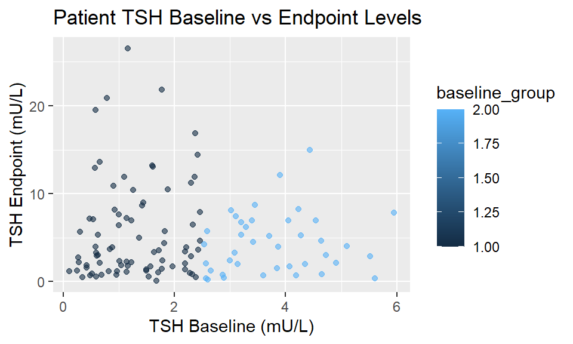

```r
ggplot(data = Updated_tsh_data,
       aes(x = tsh_baseline,
           y = tsh_endpoint,
           color = baseline_group)) +

  geom_point(alpha = 0.6) +

  labs(x = "TSH Baseline (mU/L)",
       y = "TSH Endpoint (mU/L)",
       title = "Patient TSH Baseline vs Endpoint Levels")
```

9. **Describe the association between the baseline and endpoint TSH values.**

10. **Add a variable called `TSH_group_endpoint` to the dataset categorizing the endpoint TSH values as being in the TSH groups listed below:**
- `LowNormal` TSH (0.34 to 2.50 mU/L)
- `HighNormal` TSH (2.51 to 5.60 mU/L)
- `Elevated` TSH (greater than 5.60 mU/L)

```r
#So, changing things requires using the mutate function
Answer_10 <- Updated_tsh_data %>% mutate(
  TSH_group_endpoint = case_when(
    tsh_endpoint >= 0.34 & tsh_endpoint <= 2.50 ~ "LowNormal",
    tsh_endpoint >= 2.51 & tsh_endpoint <= 5.60 ~ "HighNormal",
    tsh_endpoint > 5.60 ~ "Elevated")
  )

Answer_10
```

```
## # A tibble: 120 x 9
##       id baseline_group Arms    age gender menstrual tsh_baseline tsh_endpoint
##    <dbl>          <dbl> <chr> <dbl> <chr>      <dbl>        <dbl>        <dbl>
##  1     1              1 Arm1   30.8 f              1         1.05         1.87
##  2     2              1 Arm2   50.4 f              3         1.78         1.49
##  3     3              1 Arm1   55.4 f              3         2.43         3.62
##  4     4              1 Arm2   33.0 f              2         2.3          2.9
##  5     6              1 Arm3   28.4 f              1         0.63         3.02
##  6     7              1 Arm1   44.8 f              1         0.27         2.72
##  7     8              1 Arm2   42.9 f              1         2.46         4.66
##  8     9              1 Arm3   50.0 f              1         0.42         1.58
##  9    10              2 Arm1   51.3 f              3         2.89         0.43
## 10    11              1 Arm3   51.1 f              4         0.61         2.95
## # ... with 110 more rows, and 1 more variable: TSH_group_endpoint <chr>
```

11. **Calculate minimum and maximum summary statistics for the endpoint TSH values stratified by `TSH_group_endpoint`. Do the min and max values agree with the group values listed above?**

```r
Answer_10 %>% group_by(TSH_group_endpoint) %>%
  summarise(min = min(tsh_endpoint), max = max(tsh_endpoint))
```

```
## # A tibble: 4 x 3
##   TSH_group_endpoint   min   max
##   <chr>              <dbl> <dbl>
## 1 Elevated            5.65 26.5
## 2 HighNormal          2.72  5.32
## 3 LowNormal           0.35  2.43
## 4 <NA>                0.1   0.26
```

Yes, it does! (That’s exciting.)

12. **Make a contingency table of the TSH baseline vs. endpoint groups, that includes row and column totals.**

```r
#Am I to assume here that I use the same categorization for tsh_group_baseline as the values in tsh_group_endpoint????? Based on this question, I have to make a tsh_group_baseline first in order for me to compare things...

Answer_12 <- Answer_10 %>% mutate(
  TSH_group_baseline = case_when(
    tsh_baseline >= 0.34 & tsh_baseline <= 2.50 ~ "LowNormal baseline",
    tsh_baseline >= 2.51 & tsh_baseline <= 5.60 ~ "HighNormal baseline",
    tsh_baseline > 5.60 ~ "Elevated baseline")
  )

#Print
Answer_12
```

```
## # A tibble: 120 x 10
##       id baseline_group Arms    age gender menstrual tsh_baseline tsh_endpoint
##    <dbl>          <dbl> <chr> <dbl> <chr>      <dbl>        <dbl>        <dbl>
##  1     1              1 Arm1   30.8 f              1         1.05         1.87
##  2     2              1 Arm2   50.4 f              3         1.78         1.49
##  3     3              1 Arm1   55.4 f              3         2.43         3.62
##  4     4              1 Arm2   33.0 f              2         2.3          2.9
##  5     6              1 Arm3   28.4 f              1         0.63         3.02
##  6     7              1 Arm1   44.8 f              1         0.27         2.72
##  7     8              1 Arm2   42.9 f              1         2.46         4.66
##  8     9              1 Arm3   50.0 f              1         0.42         1.58
##  9    10              2 Arm1   51.3 f              3         2.89         0.43
## 10    11              1 Arm3   51.1 f              4         0.61         2.95
## # ... with 110 more rows, and 2 more variables: TSH_group_endpoint <chr>,
## #   TSH_group_baseline <chr>
```

```r
#Now I have the TSH_group_baseline stratified, I think I can do a contingency table now

Answer_12 %>%
  tabyl(TSH_group_endpoint, TSH_group_baseline) %>%
  adorn_totals(c("row", "col"))
```

```
##  TSH_group_endpoint Elevated baseline HighNormal baseline LowNormal baseline
##            Elevated                 1                  12                 28
##          HighNormal                 0                  11                 16
##           LowNormal                 0                  15                 30
##                <NA>                 0                   1                  1
##               Total                 1                  39                 75
##  NA_ Total
##    1    42
##    1    28
##    3    48
##    0     2
##    5   120
```

13. **What percent of people that started in the high normal TSH group ended in the low normal TSH group?**

14. **What percent of people that started in the low normal TSH group ended in the elevated TSH group?**